# Task 1 - House Price Prediction

### Submitted by - Shivank Udayawal

## Problem Statement :

- Predicting the Boston Housing Price.

## About Dataset :

- The Boston Housing Dataset is a derived from information collected by the U.S. Census Service concerning housing in the area of Boston MA.
- The following describes the dataset columns:
  1. CRIM - per capita crime rate by town
  2. ZN - proportion of residential land zoned for lots over 25,000 sq.ft.
  3. INDUS - proportion of non-retail business acres per town.
  4. CHAS - Charles River dummy variable (1 if tract bounds river; 0 otherwise)
  5. NOX - nitric oxides concentration (parts per 10 million)
  6. RM - average number of rooms per dwelling
  7. AGE - proportion of owner-occupied units built prior to 1940
  8. DIS - weighted distances to five Boston employment centres
  9. RAD - index of accessibility to radial highways
  10. TAX - full-value property-tax rate per $10,000
  11. PTRATIO - pupil-teacher ratio by town
  12. B - 1000(Bk - 0.63)^2 where Bk is the proportion of blacks by town
  13. LSTAT - % lower status of the population
  14. MEDV - Median value of owner-occupied homes in $1000's

## Importing Libraries

```python
import numpy as np
import matplotlib.pyplot as plt
import pandas as pd
import seaborn as sns
%matplotlib inline

import warnings
warnings.filterwarnings("ignore")
```

## Loading the Dataset

```python
from sklearn.datasets import load_boston
boston_dataset = load_boston()
```

## Reading the Data

```python
Data_boston = pd.DataFrame(boston_dataset.data, columns = boston_dataset.feature_names)
Data_boston.head()
```

|  | CRIM | ZN | INDUS | CHAS | NOX | RM | AGE | DIS | RAD | TAX | PTRATIO | B | LSTAT |
| --- | --- | --- | --- | --- | --- | --- | --- | --- | --- | --- | --- | --- | --- |
| 0 | 0.00632 | 18.0 | 2.31 | 0.0 | 0.538 | 6.575 | 65.2 | 4.0900 | 1.0 | 296.0 | 15.3 | 396.90 | 4.98 |
| 1 | 0.02731 | 0.0 | 7.07 | 0.0 | 0.469 | 6.421 | 78.9 | 4.9671 | 2.0 | 242.0 | 17.8 | 396.90 | 9.14 |
| 2 | 0.02729 | 0.0 | 7.07 | 0.0 | 0.469 | 7.185 | 61.1 | 4.9671 | 2.0 | 242.0 | 17.8 | 392.83 | 4.03 |
| 3 | 0.03237 | 0.0 | 2.18 | 0.0 | 0.458 | 6.998 | 45.8 | 6.0622 | 3.0 | 222.0 | 18.7 | 394.63 | 2.94 |
| 4 | 0.06905 | 0.0 | 2.18 | 0.0 | 0.458 | 7.147 | 54.2 | 6.0622 | 3.0 | 222.0 | 18.7 | 396.90 | 5.33 |

- The Prices of the House indicated by the variable MEDV is our target variable and the remaining are the feature variables based on which we will predict the value of a house.
- Target value MEDV is missing from the data.

```python
Data_boston['MEDV'] = boston_dataset.target
```

```python
Data_boston.head()
```

|  | CRIM | ZN | INDUS | CHAS | NOX | RM | AGE | DIS | RAD | TAX | PTRATIO | B | LSTAT | MEDV |
| --- | --- | --- | --- | --- | --- | --- | --- | --- | --- | --- | --- | --- | --- | --- |
| 0 | 0.00632 | 18.0 | 2.31 | 0.0 | 0.538 | 6.575 | 65.2 | 4.0900 | 1.0 | 296.0 | 15.3 | 396.90 | 4.98 | 24.0 |
| 1 | 0.02731 | 0.0 | 7.07 | 0.0 | 0.469 | 6.421 | 78.9 | 4.9671 | 2.0 | 242.0 | 17.8 | 396.90 | 9.14 | 21.6 |
| 2 | 0.02729 | 0.0 | 7.07 | 0.0 | 0.469 | 7.185 | 61.1 | 4.9671 | 2.0 | 242.0 | 17.8 | 392.83 | 4.03 | 34.7 |
| 3 | 0.03237 | 0.0 | 2.18 | 0.0 | 0.458 | 6.998 | 45.8 | 6.0622 | 3.0 | 222.0 | 18.7 | 394.63 | 2.94 | 33.4 |
| 4 | 0.06905 | 0.0 | 2.18 | 0.0 | 0.458 | 7.147 | 54.2 | 6.0622 | 3.0 | 222.0 | 18.7 | 396.90 | 5.33 | 36.2 |

```python
Data_boston.shape
```

```
(506, 14)
```

## Summary of Data

```python
Data_boston.describe().T
```

|  | count | mean | std | min | 25% | 50% | 75% | max |
| --- | --- | --- | --- | --- | --- | --- | --- | --- |
| CRIM | 506.0 | 3.613524 | 8.601545 | 0.00632 | 0.082045 | 0.25651 | 3.677083 | 88.9762 |
| ZN | 506.0 | 11.363636 | 23.322453 | 0.00000 | 0.000000 | 0.00000 | 12.500000 | 100.0000 |
| INDUS | 506.0 | 11.136779 | 6.860353 | 0.46000 | 5.190000 | 9.69000 | 18.100000 | 27.7400 |
| CHAS | 506.0 | 0.069170 | 0.253994 | 0.00000 | 0.000000 | 0.00000 | 0.000000 | 1.0000 |
| NOX | 506.0 | 0.554695 | 0.115878 | 0.38500 | 0.449000 | 0.53800 | 0.624000 | 0.8710 |
| RM | 506.0 | 6.284634 | 0.702617 | 3.56100 | 5.885500 | 6.20850 | 6.623500 | 8.7800 |
| AGE | 506.0 | 68.574901 | 28.148861 | 2.90000 | 45.025000 | 77.50000 | 94.075000 | 100.0000 |
| DIS | 506.0 | 3.795043 | 2.105710 | 1.12960 | 2.100175 | 3.20745 | 5.188425 | 12.1265 |
| RAD | 506.0 | 9.549407 | 8.707259 | 1.00000 | 4.000000 | 5.00000 | 24.000000 | 24.0000 |
| TAX | 506.0 | 408.237154 | 168.537116 | 187.00000 | 279.000000 | 330.00000 | 666.000000 | 711.0000 |
| PTRATIO | 506.0 | 18.455534 | 2.164946 | 12.60000 | 17.400000 | 19.05000 | 20.200000 | 22.0000 |
| B | 506.0 | 356.674032 | 91.294864 | 0.32000 | 375.377500 | 391.44000 | 396.225000 | 396.9000 |
| LSTAT | 506.0 | 12.653063 | 7.141062 | 1.73000 | 6.950000 | 11.36000 | 16.955000 | 37.9700 |
| MEDV | 506.0 | 22.532806 | 9.197104 | 5.00000 | 17.025000 | 21.20000 | 25.000000 | 50.0000 |

- ZN have 0 from min, 25th and 50th percentiles.
- CHAS have 0 from min, 25th, 50th and 75th percentiles.
- We can say that both variables are conditional + categorical variables

## Missing Values

```python
Data_boston.isnull().sum()
```

```
CRIM       0
ZN         0
INDUS      0
CHAS       0
NOX        0
RM         0
AGE        0
DIS        0
RAD        0
TAX        0
PTRATIO    0
B          0
LSTAT      0
MEDV       0
dtype: int64
```

- Dataset have no missing values.

## Data Visualization

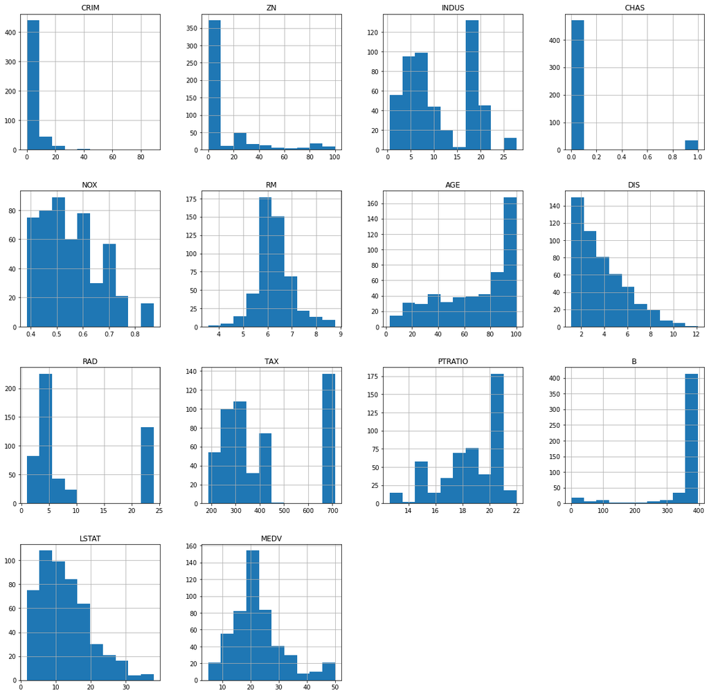

```python
Data_boston.hist(figsize = (20,20))
plt.show()
```

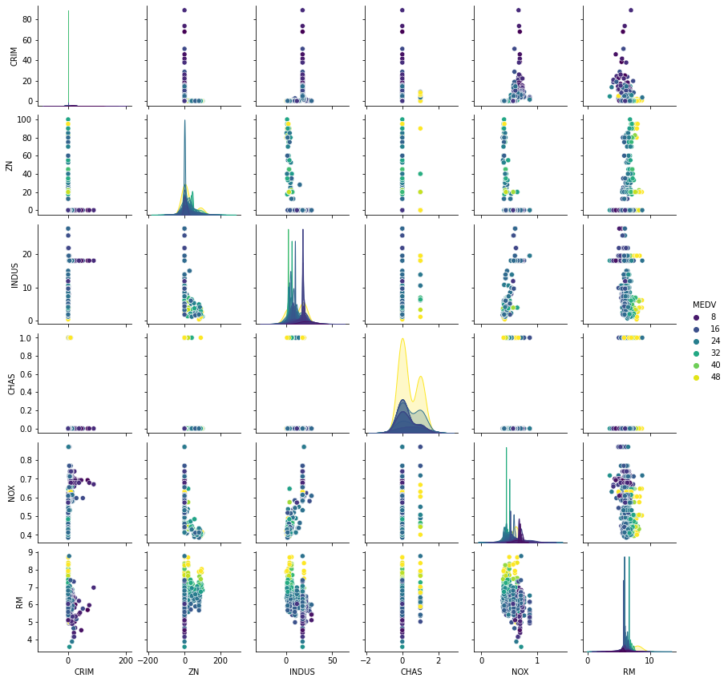

```python
imp_feats = ['MEDV','CRIM','ZN','INDUS','CHAS','NOX','RM']
sns.pairplot(Data_boston[imp_feats], hue = 'MEDV', palette = 'viridis', size = 2.0)
plt.show()
```

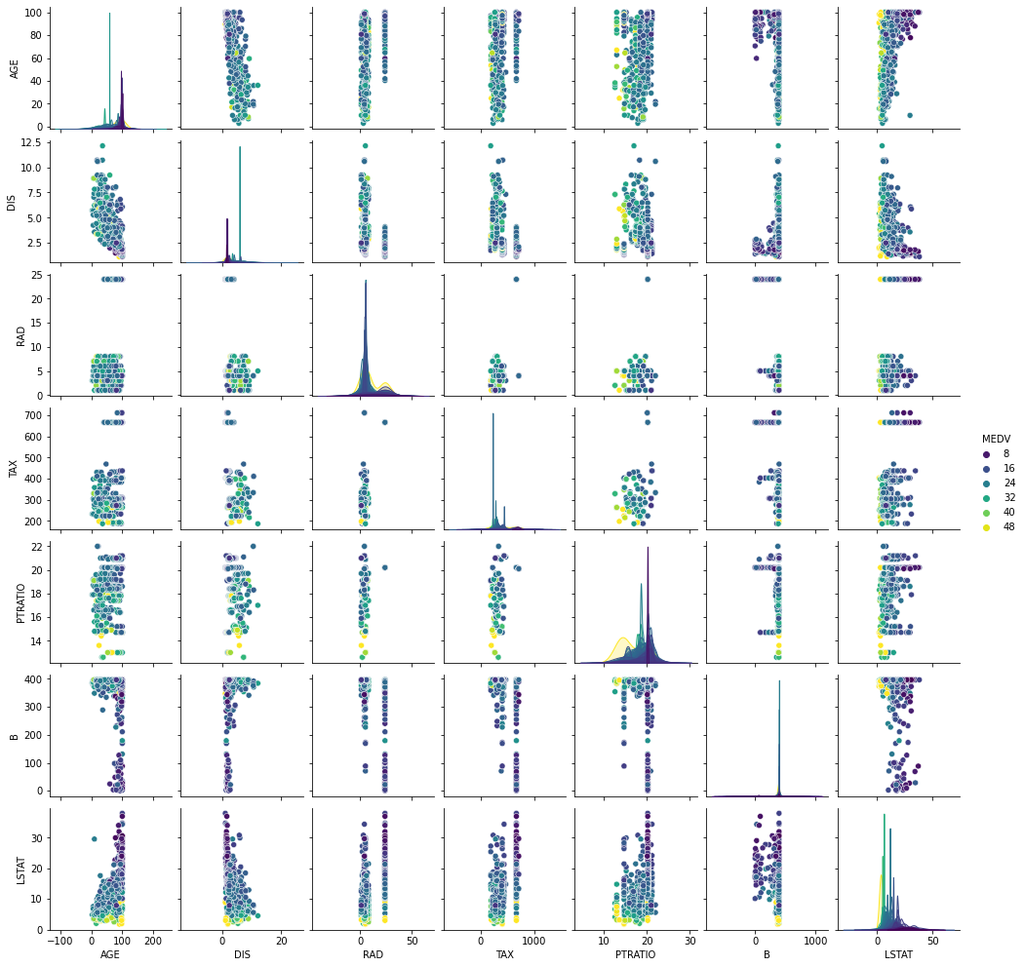

```python
imp_feats = ['MEDV','AGE','DIS','RAD','TAX','PTRATIO','B','LSTAT']
sns.pairplot(Data_boston[imp_feats], hue = 'MEDV', palette = 'viridis', size = 2.0)
plt.show()
```

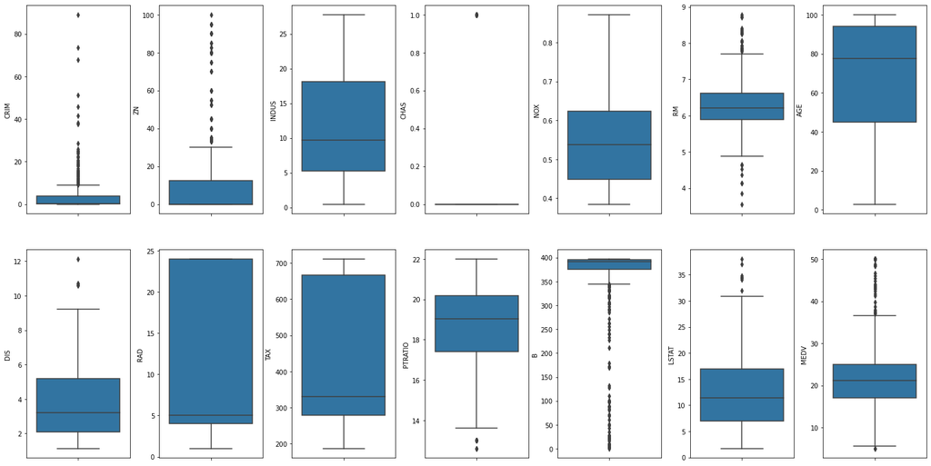

```python
fig, axs = plt.subplots(ncols = 7, nrows = 2, figsize = (20, 10))
index = 0
axs = axs.flatten()
for k,v in Data_boston.items():
    sns.boxplot(y = k, data = Data_boston, ax = axs[index])
    index += 1
plt.tight_layout(pad = 0.4, w_pad = 0.5, h_pad = 5.0)
```

```python
for k, v in Data_boston.items():
        q1 = v.quantile(0.25)
        q3 = v.quantile(0.75)
        irq = q3 - q1
        v_col = v[(v <= q1 - 1.5 * irq) | (v >= q3 + 1.5 * irq)]
        perc = np.shape(v_col)[0] * 100.0 / np.shape(Data_boston)[0]
        print("Column %s outliers = %.2f%%" % (k, perc))
```

```
Column CRIM outliers = 13.04%
Column ZN outliers = 13.44%
Column INDUS outliers = 0.00%
Column CHAS outliers = 100.00%
Column NOX outliers = 0.00%
Column RM outliers = 5.93%
Column AGE outliers = 0.00%
Column DIS outliers = 0.99%
Column RAD outliers = 0.00%
Column TAX outliers = 0.00%
Column PTRATIO outliers = 2.96%
Column B outliers = 15.22%
Column LSTAT outliers = 1.38%
Column MEDV outliers = 7.91%
```

```python
Data_boston = Data_boston[~(Data_boston['MEDV'] >= 50.0)]
print(np.shape(Data_boston))
```

```
(490, 14)
```

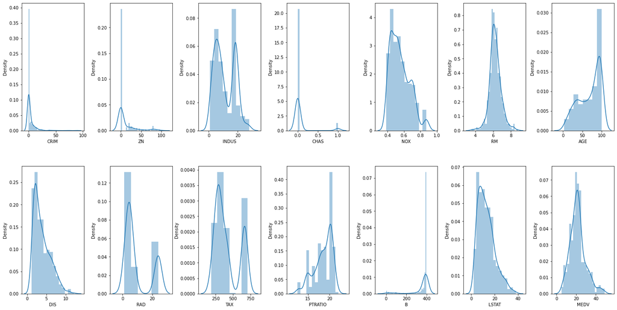

```python
fig, axs = plt.subplots(ncols = 7, nrows = 2, figsize = (20, 10))
index = 0
axs = axs.flatten()
for k,v in Data_boston.items():
    sns.distplot(v, ax = axs[index])
    index += 1
plt.tight_layout(pad = 0.4, w_pad = 0.5, h_pad = 5.0)
```

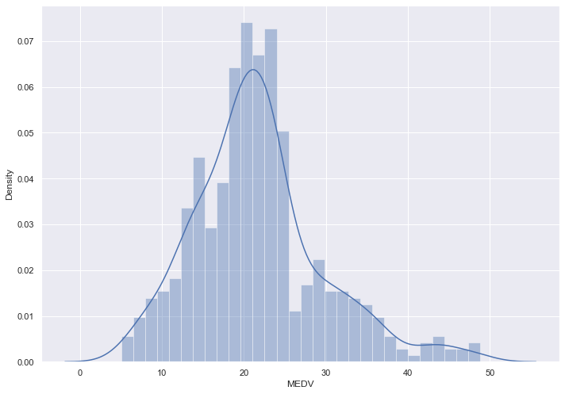

```python
sns.set(rc = {'figure.figsize':(11.7,8.27)})
sns.distplot(Data_boston['MEDV'], bins = 30)
plt.show()
```

- MEDV is Normally Distributed with few Outliers.

## Correlation Matrix

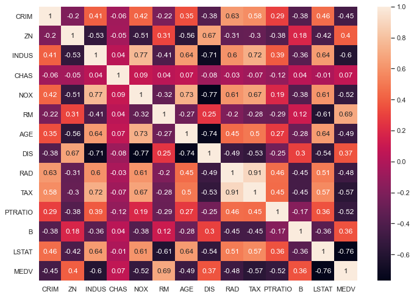

```python
correlation_matrix = Data_boston.corr().round(2)
sns.heatmap(data = correlation_matrix, annot = True)
```

- TAX and RAD are highly correlated
- LSTAT, INDUS, RM, TAX, NOX, PTRAIO has a correlation score above 0.5 with MEDV

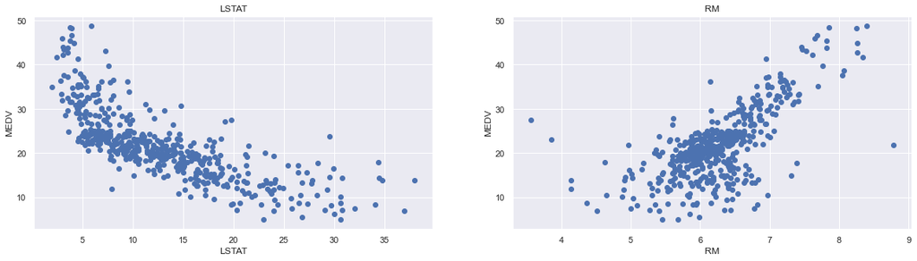

```python
plt.figure(figsize = (20, 5))
features = ['LSTAT', 'RM']
target = Data_boston['MEDV']

for i, col in enumerate(features):
    plt.subplot(1, len(features) , i+1)
    x = Data_boston[col]
    y = target
    plt.scatter(x, y, marker = 'o')
    plt.title(col)
    plt.xlabel(col)
    plt.ylabel('MEDV')
```

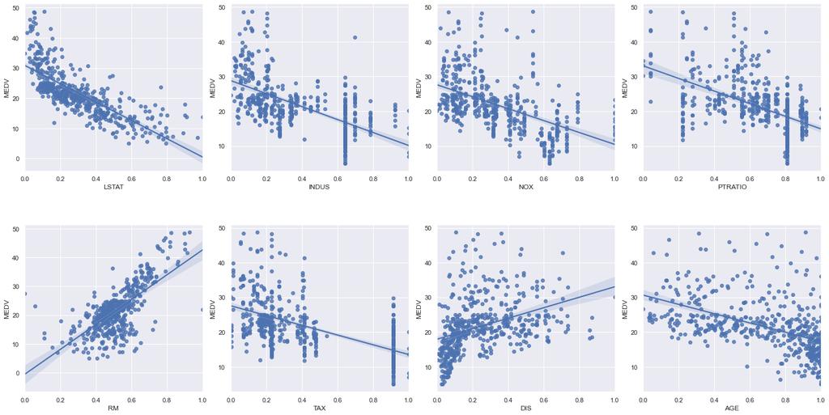

```python
from sklearn import preprocessing
min_max_scaler = preprocessing.MinMaxScaler()
column_sels = ['LSTAT', 'INDUS', 'NOX', 'PTRATIO', 'RM', 'TAX', 'DIS', 'AGE']
x = Data_boston.loc[:,column_sels]
y = Data_boston['MEDV']
x = pd.DataFrame(data = min_max_scaler.fit_transform(x), columns = column_sels)
fig, axs = plt.subplots(ncols = 4, nrows = 2, figsize = (20, 10))
index = 0
axs = axs.flatten()
for i, k in enumerate(column_sels):
    sns.regplot(y = y, x = x[k], ax = axs[i])
plt.tight_layout(pad = 0.4, w_pad = 0.5, h_pad = 5.0)
```

## PreProcessing Data

```python
X = Data_boston.drop(columns = ['MEDV'])
Y = Data_boston['MEDV']
```

## Modeling

```python
from sklearn.model_selection import train_test_split

X_train, X_test, Y_train, Y_test = train_test_split(X, Y, test_size = 0.2, random_state = 5)
print(X_train.shape)
print(X_test.shape)
print(Y_train.shape)
print(Y_test.shape)
```

```
(392, 13)
(98, 13)
(392,)
(98,)
```

## Linear Regression

```python
from sklearn.linear_model import LinearRegression
from sklearn.metrics import mean_squared_error, r2_score

lin_model = LinearRegression()
lin_model.fit(X_train, Y_train)
```

```
LinearRegression()
```

```python
intercept = print(lin_model.intercept_)

intercept
```

```
34.42141599953365
```

```python
coefficients = pd.DataFrame(lin_model.coef_, X_train.columns, columns = ['coefficients'])
coefficients
```

|  | coefficients |
| --- | --- |
| CRIM | -0.115881 |
| ZN | 0.024403 |
| INDUS | -0.096111 |
| CHAS | 0.535472 |
| NOX | -12.276879 |
| RM | 3.414786 |
| AGE | -0.032605 |
| DIS | -1.204270 |
| RAD | 0.255363 |
| TAX | -0.012591 |
| PTRATIO | -0.814694 |
| B | 0.008105 |
| LSTAT | -0.337576 |

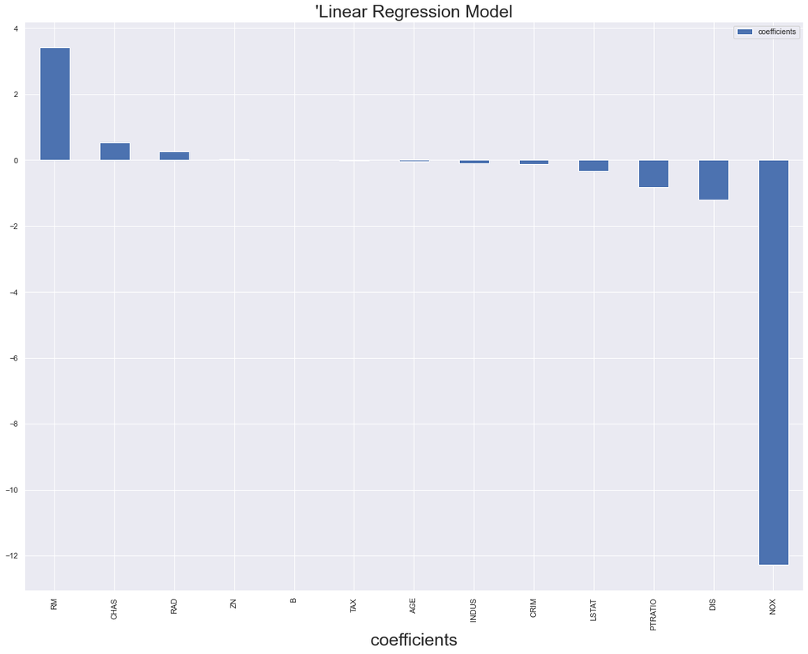

```python
coefficients.sort_values('coefficients', ascending = False, inplace = True)
coefficients.plot(kind = 'bar', figsize = (20,15))
plt.xlabel("coefficients", size = '25')
plt.title("'Linear Regression Model", size = '25')
plt.legend()
```

```python
y_test_predict = lin_model.predict(X_test)
y_test_predict - Y_test
```

```
245   -3.153054
456    0.074566
75     2.107198
238    4.948548
362   -4.424496
         ...
180   -6.626358
482    0.104195
122   -1.279397
417   -2.511565
107    0.188739
Name: MEDV, Length: 98, dtype: float64
```

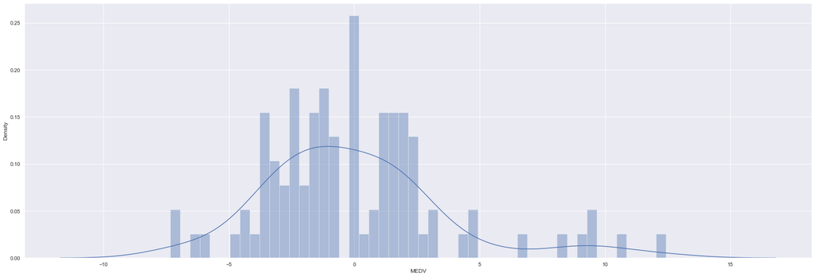

```python
plt.figure(figsize = (30,10))
sns.distplot((Y_test-y_test_predict), bins = 50);
```

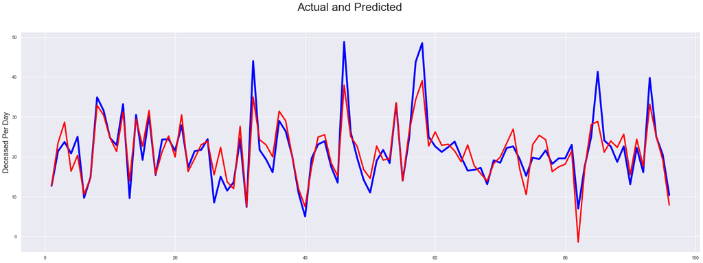

```python
c = [i for i in range(1,97,1)]
fig = plt.figure(figsize = (30,10))
plt.plot(c,Y_test[1:97], color = "blue", linewidth = 4.5, linestyle = "-")
plt.plot(c,y_test_predict[1:97], color = "red",  linewidth = 3.5, linestyle = "-")
fig.suptitle('Actual and Predicted', fontsize = 28)
plt.ylabel('Deceased Per Day', fontsize = 18)
```

## Model Evaluation

```python
from sklearn import metrics
y_train_predict = lin_model.predict(X_train)
rmse = (np.sqrt(mean_squared_error(Y_train, y_train_predict)))
r2 = r2_score(Y_train, y_train_predict)

print("\n")
print("The model performance for Training Set")
print('Mean Square Error (MSE)       :', metrics.mean_squared_error(Y_train,y_train_predict))
print('Root mean Square Error (RMSE) :', np.sqrt(metrics.mean_squared_error(Y_train,y_train_predict)))
print('R2 score is                   :', r2_score(Y_train, y_train_predict))
print("\n")

y_test_predict = lin_model.predict(X_test)
rmse = (np.sqrt(mean_squared_error(Y_test, y_test_predict)))
r2 = r2_score(Y_test, y_test_predict)

print("The model performance for Testing Set")
print('Mean Square Error (MSE)       :', metrics.mean_squared_error(Y_test,y_test_predict))
print('Root mean Square Error (RMSE) :', np.sqrt(metrics.mean_squared_error(Y_test,y_test_predict)))
print('R2 score is                   :', r2_score(Y_test, y_test_predict))
```

```
The model performance for Training Set
Mean Square Error (MSE)       : 14.03533735117099
Root mean Square Error (RMSE) : 3.7463765629166255
R2 score is                   : 0.7665679486556898


The model performance for Testing Set
Mean Square Error (MSE)       : 13.230005072163276
Root mean Square Error (RMSE) : 3.6373073931362025
R2 score is                   : 0.8057832692732443
```

- Training RMSE is 3.74
- Training R Square is 76.65%
- Test RMSE is 3.63
- Test R Square is 80.57%

```python
from sklearn.ensemble import GradientBoostingRegressor

gbm = GradientBoostingRegressor(max_depth = 2)

gbm.fit(X_train, Y_train)

gbm_pred = gbm.predict(X_test)
```

```python
gbm_pred - Y_test
```

```
245   -0.789472
456    2.367809
75     1.715711
238    0.501466
362   -2.338774
         ...
180    2.258600
482    4.552756
122   -2.032690
417   -0.977822
107   -0.149312
Name: MEDV, Length: 98, dtype: float64
```

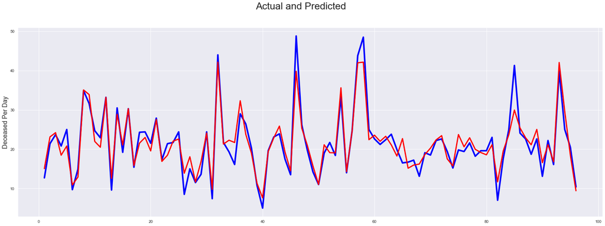

```python
c = [i for i in range(1,97,1)]
fig = plt.figure(figsize = (30,10))
plt.plot(c,Y_test[1:97], color = "blue", linewidth = 4.5, linestyle = "-")
plt.plot(c,gbm_pred[1:97], color = "red",  linewidth = 3.5, linestyle = "-")
fig.suptitle('Actual and Predicted', fontsize = 28)
plt.ylabel('Deceased Per Day', fontsize = 18)
```

## Model Evaluation

```python
from sklearn import metrics
mean_square = metrics.mean_squared_error(Y_test,gbm_pred)
r2 = r2_score(Y_test, gbm_pred)
y_train_predict = gbm.predict(X_train)

print("\n")
print('Mean Square Error (MSE) for Training Set       :', metrics.mean_squared_error(Y_train,y_train_predict))
print('Root mean Square Error (RMSE) for Training Set :', np.sqrt(metrics.mean_squared_error(Y_train,y_train_predict)))
print('R2 score for Training Set                      :', r2_score(Y_train, y_train_predict))
print("\n")

print('Mean Square Error (MSE) for Test Set           :', metrics.mean_squared_error(Y_test,gbm_pred))
print('Root mean Square Error (RMSE) for Test Set     :', np.sqrt(metrics.mean_squared_error(Y_test,gbm_pred)))
print('R2 score for Test Set                          :', r2_score(Y_test, gbm_pred))
```

```
Mean Square Error (MSE) for Training Set       : 3.794482971881539
Root mean Square Error (RMSE) for Training Set : 1.9479432671106054
R2 score for Training Set                      : 0.9368911539669218


Mean Square Error (MSE) for Test Set           : 7.097532243203455
Root mean Square Error (RMSE) for Test Set     : 2.664119412339367
R2 score for Test Set                          : 0.8958080891893931
```

- Training RMSE is 1.94
- Training R Square is 93.68%
- Test RMSE is 2.66
- Test R Square is 89.58%